# Neural Network Forecasting of Uber

In this notebook, I will develop several neural network autoregressive models to forecast the uber data. As explained previously, the seasonality in the data is not very strong. Moreover, it seems that the trend of the data changes a bit from summer 2016. As a result, I will develop for different neural network models as follows:

1 - neural network excluding seasonal lag and one trend

2- neural network including seasonal lag and one trend

3 - neural network excluding seasonal lag and piecewise linear trend

4 - neural network including seasonal lag and piecewise linear trend

It is worth mentioning that the regular lags 1, 2, 3, etc. will be included into the model. The number of such lags is determined by minimizing the AICc.

```r
source('uber_data_preprocessing.R')
```

```r
source('error_metrics.R')
```

```r
# devloping model 1
nnfit1 <- nnetar(uber_train, P=0)
# developing model 2
nnfit2 <- nnetar(uber_train, P=1)
# developing model 3
t <- seq_along(uber_train)
knot <- 141
tb <- pmax(0, t-knot)
xreg = cbind(t=t, tb=tb)
nnfit3 <- nnetar(uber_train, P=0, xreg=xreg)
# developing model 4
nnfit4 <- nnetar(uber_train, P=1, xreg=xreg)
```

Let's take a look at the structure of the models.

```r
print(nnfit1)
```

```
Series: uber_train
Model:  NNAR(3,2)
Call:   nnetar(y = uber_train, P = 0)

Average of 20 networks, each of which is
a 3-2-1 network with 11 weights
options were - linear output units

sigma^2 estimated as 17.72
```

```r
print(nnfit2)
```

```
Series: uber_train
Model:  NNAR(3,1,2)[52]
Call:   nnetar(y = uber_train, P = 1)

Average of 20 networks, each of which is
a 4-2-1 network with 13 weights
options were - linear output units

sigma^2 estimated as 19.28
```

```r
print(nnfit3)
```

```
Series: uber_train
Model:  NNAR(3,3)
Call:   nnetar(y = uber_train, P = 0, xreg = xreg)

Average of 20 networks, each of which is
a 5-3-1 network with 22 weights
options were - linear output units

sigma^2 estimated as 14.63
```

```r
print(nnfit4)
```

```
Series: uber_train
Model:  NNAR(3,1,4)[52]
Call:   nnetar(y = uber_train, P = 1, xreg = xreg)

Average of 20 networks, each of which is
a 6-4-1 network with 33 weights
options were - linear output units

sigma^2 estimated as 14.33
```

Now, let's take a look at how they fit the training data.

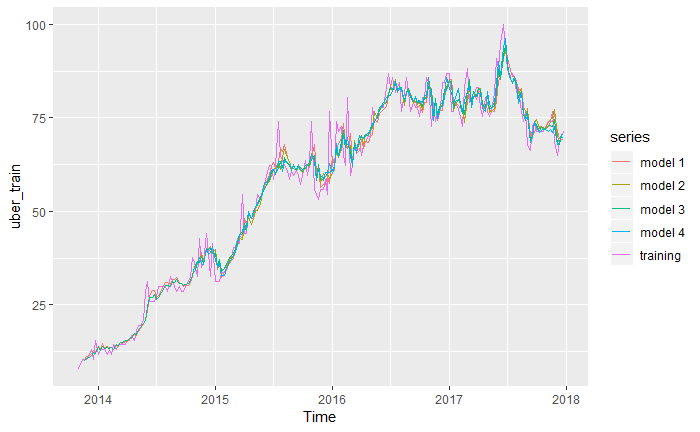

```r
autoplot(uber_train, series='training') +
autolayer(fitted(nnfit1), series='model 1') +
autolayer(fitted(nnfit2), series='model 2') +
autolayer(fitted(nnfit3), series='model 3') +
autolayer(fitted(nnfit4), series='model 4')
```

Visually, it seems that all models are doing fine. Now, let's take a look at the error metrics on the training data.

```r
accuracy(nnfit1)
```

```
                       ME    RMSE      MAE        MPE     MAPE      MASE        ACF1
Training set -0.004877724 4.20957 2.937915 -0.7173569 5.798776 0.1437398 0.005959385
```

```r
accuracy(nnfit2)
```

```
                     ME    RMSE      MAE        MPE     MAPE      MASE       ACF1
Training set 0.01608933 4.39127 3.158144 -0.5048879 4.940218 0.1545147 0.01598952
```

```r
accuracy(nnfit3)
```

```
                      ME    RMSE      MAE        MPE     MAPE     MASE       ACF1
Training set -0.00324876 3.82539 2.668267 -0.5858478 5.287396 0.130547 -0.0146064
```

```r
accuracy(nnfit4)
```

```
                      ME     RMSE      MAE        MPE     MAPE      MASE        ACF1
Training set 0.007134451 3.785852 2.872564 -0.4017154 4.453977 0.1405424 -0.01179791
```

It seems that model 4, the neural network including seasonal lag and piecewise linear trend, fits the training data the best. But, let's take a look at the cross-validation errors to decide which model outperforms the others. I will first create some functions to perform the cross-validation.

```r
fnnetar1 <- function(x,h){
    fit <- nnetar(x, p=3, P=0, size=2)
    return(forecast(fit, h=h))
}
fnnetar2 <- function(x,h){
    fit <- nnetar(x, p=3, P=1, size=2)
    return(forecast(fit, h=h))
}
fnnetar3 <- function(x,h){
    t <- seq_along(x)
    knot <- 141
    tb <- pmax(0,t-knot)
    xreg <- cbind(t,tb)
    t_new <- t[length(t)] + seq(h)
    tb_new <- tb[length(tb)] + seq(h)
    xreg_new <- cbind(t_new, tb_new)
    fit <- nnetar(x, p=3, P=0, size=3, xreg=xreg)
    fcst <- forecast(fit, xreg=xreg_new, h=h)
    return(fcst)
}
fnnetar4 <- function(x,h){
    t <- seq_along(x)
    knot <- 141
    tb <- pmax(0,t-knot)
    xreg <- cbind(t,tb)
    t_new <- t[length(t)] + seq(h)
    tb_new <- tb[length(tb)] + seq(h)
    xreg_new <- cbind(t_new, tb_new)
    fit <- nnetar(x, p=3, P=1, size=4, xreg=xreg)
    fcst <- forecast(fit, xreg=xreg_new, h=h)
    return(fcst)
}
nnfit1_e <- tsCV(uber_train, fnnetar1, h=1)
nnfit2_e <- tsCV(uber_train, fnnetar2, h=1)
nnfit3_e <- tsCV(uber_train, fnnetar3, h=1)
nnfit4_e <- tsCV(uber_train, fnnetar4, h=1)
```

In order to evaluate their performance, I select a window to make sure that the error values for all models are available and valid. Let's see the performance on the cross-validation.

```r
print(nnfit1_e %>% window(start=c(2015,27)) %>% rmse())
```

```
[1] 5.317333
```

```r
print(nnfit2_e %>% window(start=c(2015,27)) %>% rmse())
```

```
[1] 7.569627
```

```r
print(nnfit3_e %>% window(start=c(2015,27)) %>% rmse())
```

```
[1] 11.34694
```

```r
print(nnfit4_e %>% window(start=c(2015,27)) %>% rmse())
```

```
[1] 10.56515
```

As seen, model 1, neural network excluding seasonal lag and one trend, outperforms the other models on cross-validation. In fact, I believe model 3 and 4 over-fit the training data. Considering these values, I select model 1 as the best candidate. Let's take a look at the residuals for this model.

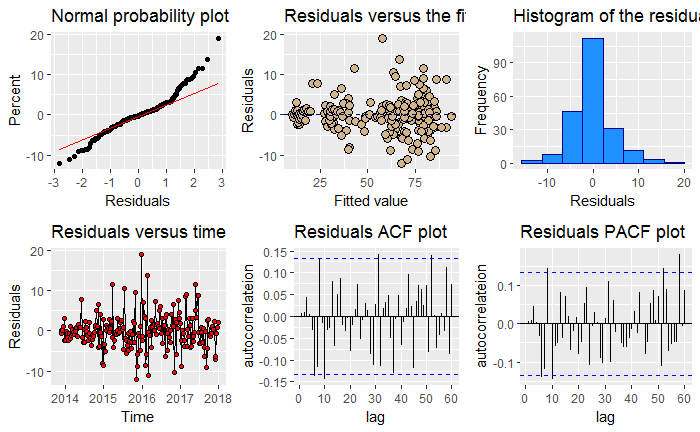

```r
residual_diagnostics_plots(nnfit1)
```

According to the residual plots:

1 - The residuals do not follow a normal distribution, suggesting that the confidence intervals may not be very accurate.

2 - Some structure could be seen in the residuals vs fitted value plot.

3- The variation in the residuals changes slightly over time.

4 - No significant spikes could be seen in the first 5 lags in ACF and PACF plots.

Based on the residuals and error metrics, I believe this model could be considered a simple and reasonable model. However, it may not be the best choice. Let's make the forecast for the year 2018.

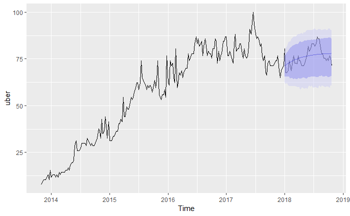

```r
nnfit1_fcst <- forecast(nnfit1, PI=TRUE, h=length(uber_test))
autoplot(uber) +
autolayer(nnfit1_fcst, alpha=0.4)
```

```r
accuracy(nnfit1_fcst, uber)
```

```
                       ME     RMSE      MAE         MPE     MAPE      MASE        ACF1 Theil's U
Training set -0.004877724 4.209570 2.937915 -0.71735693 5.798776 0.1437398 0.005959385        NA
Test set      0.277484816 4.346745 3.651477  0.02593831 4.725831 0.1786514 0.654880559  1.281994
```

The performance of this model is fine. However, it does not beat models that were previously developed such as dynamic models. In the next notebook, I will explore the models that work based on bootstrapping and bagging. Stay Tuned.